# Actividad Dirigida 3: Uso de API de Covid19 con Pandas

En esta actividad dirigida haremos uso de la [API de Covid-19](https://covid19api.com/#subscribe) creada por Kyle Redelinghuys, a través de la cual se puede consultar información en tiempo real de la evolución de la pandemia COVID-19.

Los pasos que se seguirán en este código serán los siguientes:

1. Instalación de la librería Pandas y configuración
2. Variables
3. Creación de *Dataframe*
4. Explorar tabla
5. Acceso a datos
6. Tiempo real España
7. Tiempo real Colombia
8. Comparativa España-Colombia
9. Triple comparativa España-Colombia-Argentina
10. Seleccionar más columnas
11. Exportar datos
- https://covid19api.com/
- https://api.covid19api.com/

## Instalación Pandas

Lo primero que debemos hacer es instalar la librería [Pandas](https://pandas.pydata.org) que se trata de una herramienta de análisis y manipulación de datos en código abierto construida sobre el lenguaje de programación Python. Para ello, haremos uso de la orden `!pip install pandas`, ya que el `pip` es un gestor de paquetes estándar para este lenguaje que permite que se instalen y gestionen paquetes que no forman parte de la biblioteca estándar de Python.

```python
!pip install pandas
```

## Configuración

Tras este primer paso, lo siguiente será configurar e introducir la librería de Pandas en este código y darle a pandas el alias de pd a través de la orden `import pandas as pd`.

```python
import pandas as pd
```

## Variables

En este segundo paso, lo primero que debemos hacer es definir la [URL](https://api.covid19api.com/countries) en la que queremos hacer web scraping y obtener los datos. En este usaremos la orden `url = 'https://api.covid19api.com/countries'` para recabar la lista de países en los que se muestra la evolución en tiempo real de la pandemia.

```python
url ='https://api.covid19api.com/countries'
```

```python
url
```

```
'https://api.covid19api.com/countries'
```

## Creación de *Dataframe*

En este paso, utilizamos la función `read_json` de pandas con el objetivo de leer archivos en cadena de cualquier formato (archivos comprimidos o URLs, entre otros) en JSON de la API. En este caso la lectura se realizará desde una [URL API](https://api.covid19api.com/countries) y además haremos uso de la estrucutra de datos, DataFrame, es decir, `df` para guardar la información obtenida de distintos tipos en columnas como si fuera una hoja de cálculo. Para ello, utilizaremos la siguiente función: `df = pd.read_json(url)`, y después simplemente introduciremos la orden `df` para que nos imprima la tabla de la [URL API](https://api.covid19api.com/countries) que hemos definido previamente.

```python
df = pd.read_json(url)
```

```python
df
```

|  | Country | Slug | ISO2 |
| --- | --- | --- | --- |
| 0 | Republic of Kosovo | kosovo | XK |
| 1 | Botswana | botswana | BW |
| 2 | Central African Republic | central-african-republic | CF |
| 3 | Hungary | hungary | HU |
| 4 | Peru | peru | PE |
| ... | ... | ... | ... |
| 243 | Malta | malta | MT |
| 244 | San Marino | san-marino | SM |
| 245 | Gibraltar | gibraltar | GI |
| 246 | Uganda | uganda | UG |
| 247 | Vanuatu | vanuatu | VU |

248 rows × 3 columns

## Explorar tabla

- Cabecera
- Cola
- Descripción

El siguiente paso será explorar la tabla que hemos obtenido, para que nos muestre de un Data Frame: los países que aparecen en la cabecera de la lista a través de la orden `df.head ()`, los países que aparecen en la cola a través de la orden `df.tail ()` y los datos estadísticos básicos a través de la orden `df.describe ()`.

```python
df.head ()
```

|  | Country | Slug | ISO2 |
| --- | --- | --- | --- |
| 0 | Republic of Kosovo | kosovo | XK |
| 1 | Botswana | botswana | BW |
| 2 | Central African Republic | central-african-republic | CF |
| 3 | Hungary | hungary | HU |
| 4 | Peru | peru | PE |

```python
df.tail ()
```

|  | Country | Slug | ISO2 |
| --- | --- | --- | --- |
| 243 | Malta | malta | MT |
| 244 | San Marino | san-marino | SM |
| 245 | Gibraltar | gibraltar | GI |
| 246 | Uganda | uganda | UG |
| 247 | Vanuatu | vanuatu | VU |

```python
df.describe ()
```

|  | Country | Slug | ISO2 |
| --- | --- | --- | --- |
| count | 248 | 248 | 248 |
| unique | 248 | 248 | 248 |
| top | Monaco | virgin-islands | AD |
| freq | 1 | 1 | 1 |

## Acceso a datos

En este apartado, lo que queremos es tener acceso a los datos que se encuentren bajo el nombre de **"Country"** y que estos se muestren en columnas, por lo que haremos uso del Data Frame a través de la siguiente orden: `df['Country']`.

Asimismo, en este apartado, quisimos hacer una búsqueda más concreta, por lo que no solo buscamos los datos que se encontrasen bajo el nombre de **"Country"**, sino que se imprimiera justo el país que aparece en la posición *200* de la lista a través de la orden `df['Country'][200]`, en el que el resultado fue Angola.

```python
df['Country']
```

```
0            Republic of Kosovo
1                      Botswana
2      Central African Republic
3                       Hungary
4                          Peru
                 ...
243                       Malta
244                  San Marino
245                   Gibraltar
246                      Uganda
247                     Vanuatu
Name: Country, Length: 248, dtype: object
```

```python
df['Country'][200]
```

```
'Angola'
```

## Tiempo real España

En este sexto punto, lo que queremos que es la información que se muestre en tiempo real de la evolución de la pandemia sea solo en España, por lo que se definirá una [URL](https://api.covid19api.com/country/spain/status/confirmed/live) diferente a la previamente establecida, llamada `url_es`.

Después, estableceremos la orden `df_es` en la que se obtendrá la información relativa a España a través de la estrucutra de datos Data Frame, haciendo uso de la función: `df_es = pd.read_json(url_es)`.

Finalmente, simplemente introduciremos la orden `df_es` para que nos imprima la tabla de la [URL](https://api.covid19api.com/country/spain/status/confirmed/live) que hemos definido previamente.

```python
url_es = 'https://api.covid19api.com/country/spain/status/confirmed/live'
df_es = pd.read_json(url_es)
df_es
```

|  | Country | CountryCode | Province | City | CityCode | Lat | Lon | Cases | Status | Date |
| --- | --- | --- | --- | --- | --- | --- | --- | --- | --- | --- |
| 0 | Spain | ES |  |  |  | 40.46 | -3.75 | 0 | confirmed | 2020-01-22 00:00:00+00:00 |
| 1 | Spain | ES |  |  |  | 40.46 | -3.75 | 0 | confirmed | 2020-01-23 00:00:00+00:00 |
| 2 | Spain | ES |  |  |  | 40.46 | -3.75 | 0 | confirmed | 2020-01-24 00:00:00+00:00 |
| 3 | Spain | ES |  |  |  | 40.46 | -3.75 | 0 | confirmed | 2020-01-25 00:00:00+00:00 |
| 4 | Spain | ES |  |  |  | 40.46 | -3.75 | 0 | confirmed | 2020-01-26 00:00:00+00:00 |
| ... | ... | ... | ... | ... | ... | ... | ... | ... | ... | ... |
| 794 | Spain | ES |  |  |  | 40.46 | -3.75 | 11451676 | confirmed | 2022-03-26 00:00:00+00:00 |
| 795 | Spain | ES |  |  |  | 40.46 | -3.75 | 11451676 | confirmed | 2022-03-27 00:00:00+00:00 |
| 796 | Spain | ES |  |  |  | 40.46 | -3.75 | 11451676 | confirmed | 2022-03-28 00:00:00+00:00 |
| 797 | Spain | ES |  |  |  | 40.46 | -3.75 | 11508309 | confirmed | 2022-03-29 00:00:00+00:00 |
| 798 | Spain | ES |  |  |  | 40.46 | -3.75 | 11508309 | confirmed | 2022-03-30 00:00:00+00:00 |

799 rows × 10 columns

Tras este primer paso, en el caso de España hicimos uso de diferentes funciones, con el objetivo de obtener información variada de la [URL](https://api.covid19api.com/country/spain/status/confirmed/live) definida previamente.

`df_es.info()`: Esta función Pandas es utilizada para obtener un resumen conciso del marco de datos, que en este caso se centra solo en España. De esta manera, se imprimen un total de 10 columnas en las que se encuentra dividida la información, que en este caso son: "Country", "CountryCode", "Province", "City", "CityCode", "Lat", "Lon", "Cases", "Status" y "Date".

```python
df_es.info()
```

```
<class 'pandas.core.frame.DataFrame'>
RangeIndex: 799 entries, 0 to 798
Data columns (total 10 columns):
 #   Column       Non-Null Count  Dtype
---  ------       --------------  -----
 0   Country      799 non-null    object
 1   CountryCode  799 non-null    object
 2   Province     799 non-null    object
 3   City         799 non-null    object
 4   CityCode     799 non-null    object
 5   Lat          799 non-null    float64
 6   Lon          799 non-null    float64
 7   Cases        799 non-null    int64
 8   Status       799 non-null    object
 9   Date         799 non-null    datetime64[ns, UTC]
dtypes: datetime64[ns, UTC](1), float64(2), int64(1), object(6)
memory usage: 62.5+ KB
```

`df_es.set_index('Date')`: Esta función se utiliza para mostrar la columna **"Date"** como índice de la tabla y después se imprimiran el resto de columnas del marco de datos.

```python
df_es.set_index('Date')
```

| Date | Country | CountryCode | Province | City | CityCode | Lat | Lon | Cases | Status |
| --- | --- | --- | --- | --- | --- | --- | --- | --- | --- |
| 2020-01-22 00:00:00+00:00 | Spain | ES |  |  |  | 40.46 | -3.75 | 0 | confirmed |
| 2020-01-23 00:00:00+00:00 | Spain | ES |  |  |  | 40.46 | -3.75 | 0 | confirmed |
| 2020-01-24 00:00:00+00:00 | Spain | ES |  |  |  | 40.46 | -3.75 | 0 | confirmed |
| 2020-01-25 00:00:00+00:00 | Spain | ES |  |  |  | 40.46 | -3.75 | 0 | confirmed |
| 2020-01-26 00:00:00+00:00 | Spain | ES |  |  |  | 40.46 | -3.75 | 0 | confirmed |
| ... | ... | ... | ... | ... | ... | ... | ... | ... | ... |
| 2022-03-26 00:00:00+00:00 | Spain | ES |  |  |  | 40.46 | -3.75 | 11451676 | confirmed |
| 2022-03-27 00:00:00+00:00 | Spain | ES |  |  |  | 40.46 | -3.75 | 11451676 | confirmed |
| 2022-03-28 00:00:00+00:00 | Spain | ES |  |  |  | 40.46 | -3.75 | 11451676 | confirmed |
| 2022-03-29 00:00:00+00:00 | Spain | ES |  |  |  | 40.46 | -3.75 | 11508309 | confirmed |
| 2022-03-30 00:00:00+00:00 | Spain | ES |  |  |  | 40.46 | -3.75 | 11508309 | confirmed |

799 rows × 9 columns

`df_es.set_index('Date')['Cases']`: Esta función se utiliza para mostrar la columna **"Date"** como índice de la tabla y que después aparezca la información relativa a los **"Cases"**.

```python
df_es.set_index('Date')['Cases']
```

```
Date
2020-01-22 00:00:00+00:00           0
2020-01-23 00:00:00+00:00           0
2020-01-24 00:00:00+00:00           0
2020-01-25 00:00:00+00:00           0
2020-01-26 00:00:00+00:00           0
                               ...
2022-03-26 00:00:00+00:00    11451676
2022-03-27 00:00:00+00:00    11451676
2022-03-28 00:00:00+00:00    11451676
2022-03-29 00:00:00+00:00    11508309
2022-03-30 00:00:00+00:00    11508309
Name: Cases, Length: 799, dtype: int64
```

`df_es.set_index('Date')['Cases'].plot()`: Al igual que en la función anterior, esta se utiliza para mostrar la columna **"Date"** como índice de la tabla y que después aparezca la información relativa a los **"Cases"**. Además, se añade la orden `.plot()` para que la información se dibuje en un polígono con los vértices dados por las coordenadas de la lista x ("date") y de la lista y ("cases").

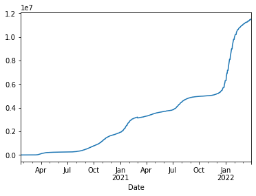

```python
df_es.set_index('Date')['Cases'].plot()
```

`df_es.set_index('Date')['Cases'].plot(title='Casos de Covid19 en España')`: Esta función sirve para lo mismo que la mencionada previamente, pero en este caso, se le añade el título "Casos de Covid19 en España" a dicho gráfico.

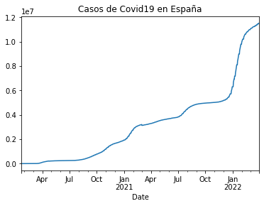

```python
df_es.set_index('Date')['Cases'].plot(title='Casos de Covid19 en España')
```

## Tiempo real Colombia

Al igual que el paso anterior, en este lo que queremos que es la información que se muestre en tiempo real de la evolución de la pandemia sea solo en Colombia, por lo que se definirá una [URL](https://api.covid19api.com/country/colombia/status/confirmed/live) diferente a la previamente establecida, llamada `url_co`.

Asimismo, estableceremos la orden `df_co` en la que se obtendrá la información relativa a Colombia a través de la estrucutra de datos Data Frame, haciendo uso de la función: `df_co = pd.read_json(url_co)`.

Finalmente, haremos uso de la función `df_co.set_index('Date')['Cases'].plot(title='Casos de Covid19 en Colombia')` para que se muestre la columna **"Date"** como índice de la tabla y que después aparezca la información relativa a los **"Cases"**, y toda esta información se dibuje en un gráfico a través de la orden `.plot()` con el título de "Casos de Covid19 en Colombia".

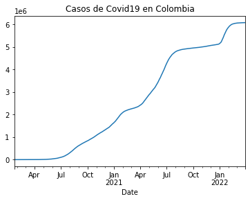

```python
url_co = 'https://api.covid19api.com/country/colombia/status/confirmed/live'
df_co = pd.read_json(url_co)
df_co.set_index('Date')['Cases'].plot(title='Casos de Covid19 en Colombia')
```

## Comparativa España-Colombia

En este apartado, comparemos la información en tiempo real de la evolución de la pandemia en España y en Colombia. Para ello, definiremos la función `df_es.set_index('Date')['Cases']` como `casos_es` en el caso de España y la función `df_co.set_index('Date')['Cases']` como `casos_co` para los datos de Colombia.

Para poder hacer la comparación de ambos dataframes a lo largo de la fila `axis = 1`, debemos hacer uso de la siguiente función: `pd.concat([casos_es,casos_co],axis=1)` y la definiremos como `vs`. Tras este paso, simplemente introduciremos la orden `vs` para que nos imprima la tabla comparativa de ambos países.

```python
casos_es = df_es.set_index('Date')['Cases']
casos_co = df_co.set_index('Date')['Cases']
```

```python
pd.concat([casos_es,casos_co],axis=1)
```

| Date | Cases | Cases |
| --- | --- | --- |
| 2020-01-22 00:00:00+00:00 | 0 | 0 |
| 2020-01-23 00:00:00+00:00 | 0 | 0 |
| 2020-01-24 00:00:00+00:00 | 0 | 0 |
| 2020-01-25 00:00:00+00:00 | 0 | 0 |
| 2020-01-26 00:00:00+00:00 | 0 | 0 |
| ... | ... | ... |
| 2022-03-26 00:00:00+00:00 | 11451676 | 6083291 |
| 2022-03-27 00:00:00+00:00 | 11451676 | 6083643 |
| 2022-03-28 00:00:00+00:00 | 11451676 | 6083939 |
| 2022-03-29 00:00:00+00:00 | 11508309 | 6084240 |
| 2022-03-30 00:00:00+00:00 | 11508309 | 6084551 |

799 rows × 2 columns

```python
vs = pd.concat([casos_es,casos_co],axis=1)
vs
```

| Date | Cases | Cases |
| --- | --- | --- |
| 2020-01-22 00:00:00+00:00 | 0 | 0 |
| 2020-01-23 00:00:00+00:00 | 0 | 0 |
| 2020-01-24 00:00:00+00:00 | 0 | 0 |
| 2020-01-25 00:00:00+00:00 | 0 | 0 |
| 2020-01-26 00:00:00+00:00 | 0 | 0 |
| ... | ... | ... |
| 2022-03-26 00:00:00+00:00 | 11451676 | 6083291 |
| 2022-03-27 00:00:00+00:00 | 11451676 | 6083643 |
| 2022-03-28 00:00:00+00:00 | 11451676 | 6083939 |
| 2022-03-29 00:00:00+00:00 | 11508309 | 6084240 |
| 2022-03-30 00:00:00+00:00 | 11508309 | 6084551 |

799 rows × 2 columns

Como en ambas columnas aparecían tituladas bajo el nombre de **"Cases"**, a través de la función `vs.columns = ['España', 'Colombia']` diferenciamos ambos títulos, estableciendo para la primera columna el nombre de España y para la segunda, Colombia. Tras este paso, simplemente introduciremos la orden `vs` para que nos imprima la tabla comparativa de ambos países.

```python
vs.columns = ['España', 'Colombia']
vs
```

| Date | España | Colombia |
| --- | --- | --- |
| 2020-01-22 00:00:00+00:00 | 0 | 0 |
| 2020-01-23 00:00:00+00:00 | 0 | 0 |
| 2020-01-24 00:00:00+00:00 | 0 | 0 |
| 2020-01-25 00:00:00+00:00 | 0 | 0 |
| 2020-01-26 00:00:00+00:00 | 0 | 0 |
| ... | ... | ... |
| 2022-03-26 00:00:00+00:00 | 11451676 | 6083291 |
| 2022-03-27 00:00:00+00:00 | 11451676 | 6083643 |
| 2022-03-28 00:00:00+00:00 | 11451676 | 6083939 |
| 2022-03-29 00:00:00+00:00 | 11508309 | 6084240 |
| 2022-03-30 00:00:00+00:00 | 11508309 | 6084551 |

799 rows × 2 columns

Finalmente, con el objetivo de poder visualizar esta comparativa en un gráfico, estableceremos la siguiente función: `vs.plot(title='España vs Colombia',kind='area')`. El método plot de Pandas tiene un parámetro kind que nos ayuda a cambiar el tipo de gráfico que queremos dibujar, que en este caso será el de tipo área.

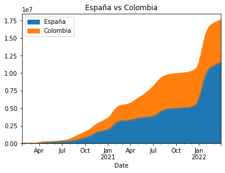

```python
vs.plot(title='España vs Colombia',kind='area')
```

## Triple comparativa España-Colombia-Argentina

En este apartado, comparemos la información en tiempo real de la evolución de la pandemia en España, en Colombia y Argentina. Para ello, definiremos la función `df_es.set_index('Date')['Cases']` como `casos_es` en el caso de España, la función `df_co.set_index('Date')['Cases']` como `casos_co` para los datos de Colombia y la función de `df_ag.set_index('Date')['Cases']`como `casos_ag`.

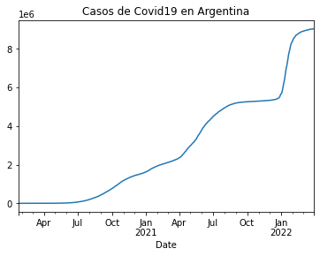

```python
url_ag = 'https://api.covid19api.com/country/argentina/status/confirmed/live'
df_ag = pd.read_json(url_ag)
df_ag.set_index('Date')['Cases'].plot(title='Casos de Covid19 en Argentina')
```

```python
casos_es = df_es.set_index('Date')['Cases']
casos_co = df_co.set_index('Date')['Cases']
casos_ag = df_ag.set_index('Date')['Cases']
```

Para poder hacer la concatenación de los tres dataframes a lo largo de la fila `axis = 1`, debemos hacer uso de la siguiente función: `pd.concat([casos_es,casos_co,casos_ag],axis=1)` y la definiremos como `vs2`. Tras este paso, simplemente introduciremos la orden `vs2` para que nos imprima la tabla comparativa de los tres países.

```python
pd.concat([casos_es,casos_co,casos_ag],axis=1)
```

| Date | Cases | Cases | Cases |
| --- | --- | --- | --- |
| 2020-01-22 00:00:00+00:00 | 0.0 | 0.0 | 0 |
| 2020-01-23 00:00:00+00:00 | 0.0 | 0.0 | 0 |
| 2020-01-24 00:00:00+00:00 | 0.0 | 0.0 | 0 |
| 2020-01-25 00:00:00+00:00 | 0.0 | 0.0 | 0 |
| 2020-01-26 00:00:00+00:00 | 0.0 | 0.0 | 0 |
| ... | ... | ... | ... |
| 2022-03-27 00:00:00+00:00 | 11451676.0 | 6083643.0 | 9026075 |
| 2022-03-28 00:00:00+00:00 | 11451676.0 | 6083939.0 | 9028730 |
| 2022-03-29 00:00:00+00:00 | 11508309.0 | 6084240.0 | 9032162 |
| 2022-03-30 00:00:00+00:00 | 11508309.0 | 6084551.0 | 9035127 |
| 2022-03-31 00:00:00+00:00 | NaN | NaN | 9035127 |

800 rows × 3 columns

```python
vs2 = pd.concat([casos_es,casos_co,casos_ag],axis=1)
vs2
```

| Date | Cases | Cases | Cases |
| --- | --- | --- | --- |
| 2020-01-22 00:00:00+00:00 | 0.0 | 0.0 | 0 |
| 2020-01-23 00:00:00+00:00 | 0.0 | 0.0 | 0 |
| 2020-01-24 00:00:00+00:00 | 0.0 | 0.0 | 0 |
| 2020-01-25 00:00:00+00:00 | 0.0 | 0.0 | 0 |
| 2020-01-26 00:00:00+00:00 | 0.0 | 0.0 | 0 |
| ... | ... | ... | ... |
| 2022-03-27 00:00:00+00:00 | 11451676.0 | 6083643.0 | 9026075 |
| 2022-03-28 00:00:00+00:00 | 11451676.0 | 6083939.0 | 9028730 |
| 2022-03-29 00:00:00+00:00 | 11508309.0 | 6084240.0 | 9032162 |
| 2022-03-30 00:00:00+00:00 | 11508309.0 | 6084551.0 | 9035127 |
| 2022-03-31 00:00:00+00:00 | NaN | NaN | 9035127 |

800 rows × 3 columns

Como las tres columnas aparecían tituladas bajo el nombre de **"Cases"**, a través de la función `vs.columns = ['España', 'Colombia', 'Argentina']` diferenciamos ambos títulos, estableciendo para la primera columna el nombre de España, la segunda el de Colombia y la tercerda el de Argentina.

```python
vs2.columns = ['España', 'Colombia', 'Argentina']
vs2
```

| Date | España | Colombia | Argentina |
| --- | --- | --- | --- |
| 2020-01-22 00:00:00+00:00 | 0.0 | 0.0 | 0 |
| 2020-01-23 00:00:00+00:00 | 0.0 | 0.0 | 0 |
| 2020-01-24 00:00:00+00:00 | 0.0 | 0.0 | 0 |
| 2020-01-25 00:00:00+00:00 | 0.0 | 0.0 | 0 |
| 2020-01-26 00:00:00+00:00 | 0.0 | 0.0 | 0 |
| ... | ... | ... | ... |
| 2022-03-27 00:00:00+00:00 | 11451676.0 | 6083643.0 | 9026075 |
| 2022-03-28 00:00:00+00:00 | 11451676.0 | 6083939.0 | 9028730 |
| 2022-03-29 00:00:00+00:00 | 11508309.0 | 6084240.0 | 9032162 |
| 2022-03-30 00:00:00+00:00 | 11508309.0 | 6084551.0 | 9035127 |
| 2022-03-31 00:00:00+00:00 | NaN | NaN | 9035127 |

800 rows × 3 columns

Finalmente, con el objetivo de poder visualizar esta comparativa en un gráfico, estableceremos la siguiente función: `vs2.plot(title='España, Colombia y Argentina')`. El método plot de Pandas le pondremos el título de "España, Colombia y Argentina".

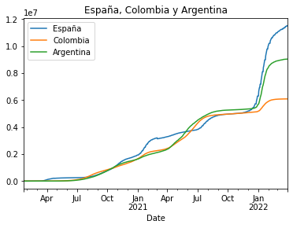

```python
vs2.plot(title='España, Colombia y Argentina')
```

## Seleccionar más columnas

En este apartado, haremos uso de la función: `df_es.set_index('Date')[['Cases','Lon']]`. Esta obtendrá los datos de España, mostrando la columna **"Date"** como índice de la tabla y después aparecerá la información relativa a los casos (**"Cases"**) y la longitud (**"Lon"**) en las columnas siguientes.

```python
df_es.set_index('Date')[['Cases','Lon']]
```

| Date | Cases | Lon |
| --- | --- | --- |
| 2020-01-22 00:00:00+00:00 | 0 | -3.75 |
| 2020-01-23 00:00:00+00:00 | 0 | -3.75 |
| 2020-01-24 00:00:00+00:00 | 0 | -3.75 |
| 2020-01-25 00:00:00+00:00 | 0 | -3.75 |
| 2020-01-26 00:00:00+00:00 | 0 | -3.75 |
| ... | ... | ... |
| 2022-03-26 00:00:00+00:00 | 11451676 | -3.75 |
| 2022-03-27 00:00:00+00:00 | 11451676 | -3.75 |
| 2022-03-28 00:00:00+00:00 | 11451676 | -3.75 |
| 2022-03-29 00:00:00+00:00 | 11508309 | -3.75 |
| 2022-03-30 00:00:00+00:00 | 11508309 | -3.75 |

799 rows × 2 columns

## Exportar datos

En este último paso, haremos uso de las funciones `vs.to_csv('vs.csv')`y `vs2.to_csv('vs2.csv')` para guardar ambas comparativas en un archivo CSV (valores separados por comas), el cuál tiene un formato específico que permite agrupar los datos en un formato de tabla estructurada.

```python
vs.to_csv('vs.csv')
```

```python
vs2.to_csv('vs2.csv')
```

Por último, además de los datos, también guardamos los gráficos relativos a ambas comparativas como archivo png, es decir, como una imagen, utilizando la siguiente función:

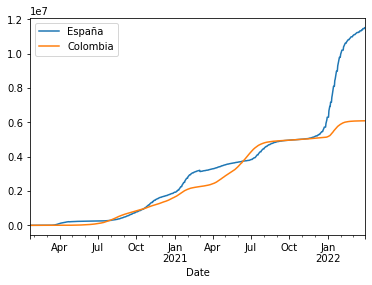

```python
grafico =vs.plot()
fig = grafico.get_figure()
fig.savefig('vs.png')
```

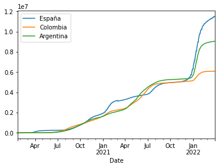

```python
grafico =vs2.plot()
fig = grafico.get_figure()
fig.savefig('vs2.png')
```